# Project Python Foundations: FoodHub Data Analysis

### **Question 9**: What percentage of the orders cost more than 20 dollars? [2 marks]

```python
# Create a count for orders that cost more than $20
cost_over_twenty = df[df['cost_of_the_order']>20].shape[0]
cost_over_twenty

# Total number of all orders
total_orders = df['order_id'].count()
total_orders

# Calculate a percentage of orders over $20
cost_percentage_above20 =  round((cost_over_twenty/total_orders)*100,2)
cost_percentage_above20
```

```
555
```

```
1898
```

```
29.24
```

**Observations**

```python
print("The amount of orders that cost over $20 is", cost_over_twenty,end='.')
print()
print("The total amount of orders is", total_orders,end='.')
print()
print(cost_percentage_above20,end="% of orders cost more than $20.")
```

```
The amount of orders that cost over $20 is 555.
The total amount of orders is 1898.
29.24% of orders cost more than $20.
```

### **Question 10**: What is the mean order delivery time? [1 mark]

```python
# Calculate average delivery time using .mean()
average_delivery_time = df["delivery_time"].mean().round(2)
average_delivery_time
```

```
24.16
```

**Observations**

```python
print("The average delivers time for orders is",average_delivery_time,end =" minutes.")
```

```
The average delivers time for orders is 24.16 minutes.
```

The average delivery time is 24.16 minutes.

### **Question 11:** The company has decided to give 20% discount vouchers to the top 3 most frequent customers. Find the IDs of these customers and the number of orders they placed. [1 mark]

```python
# Groupby customer id and order count to get an order count by customer id
most_frequent_customers = df[['customer_id','order_id']].groupby('customer_id').count().sort_values(by ='order_id', ascending = False).head(3).reset_index()

# Rename ordere_id column order_count
most_frequent_customers.rename(columns={'order_id': 'order_count'}, inplace=True)
print(most_frequent_customers)
```

```
  customer_id  order_count
0       52832           13
1       47440           10
2       83287            9
```

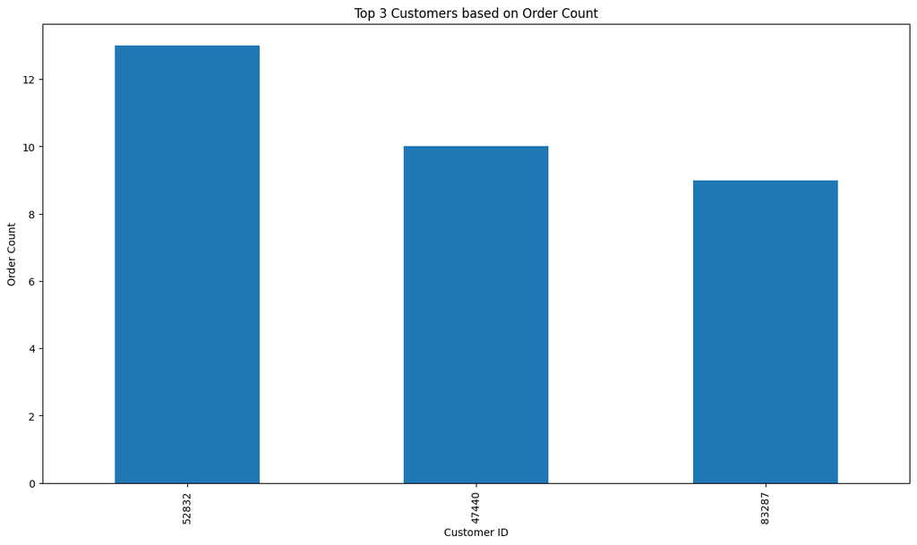

```python
# Bar graph that shows the most frequent customers
plt.figure(figsize=(15,8))
df['customer_id'].value_counts()[:3].plot(kind='bar')
plt.xlabel('Customer ID')
plt.ylabel('Order Count')
plt.title('Top 3 Customers based on Order Count')
plt.xticks(rotation=90)
plt.show();
```

**Observations**

```python
print('The top 3 customers based on oder count are 52832 (placed 13 orders), 47440 (placed 10 orders), and 83287 (placed 9 orders).')
```

```
The top 3 customers based on oder count are 52832 (placed 13 orders), 47440 (placed 10 orders), and 83287 (placed 9 orders).
```

### **Question 12**: Perform a multivariate analysis to explore relationships between the important variables in the dataset. (It is a good idea to explore relations between numerical variables as well as relations between numerical and categorical variables) [10 marks]

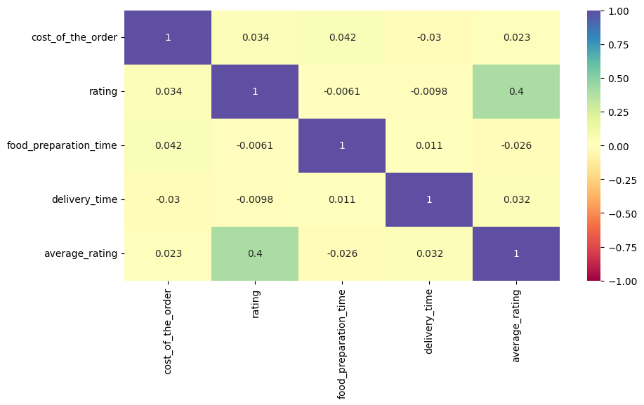

```python
plt.figure(figsize=(10,5))
sns.heatmap(df.corr(),annot=True,cmap='Spectral',vmin=-1,vmax=1)
plt.show()
```

```python
print ('Based on the heatmap there is very little correlation between the variables that were tested.')
```

```
Based on the heatmap there is very little correlation between the variables that were tested.
```

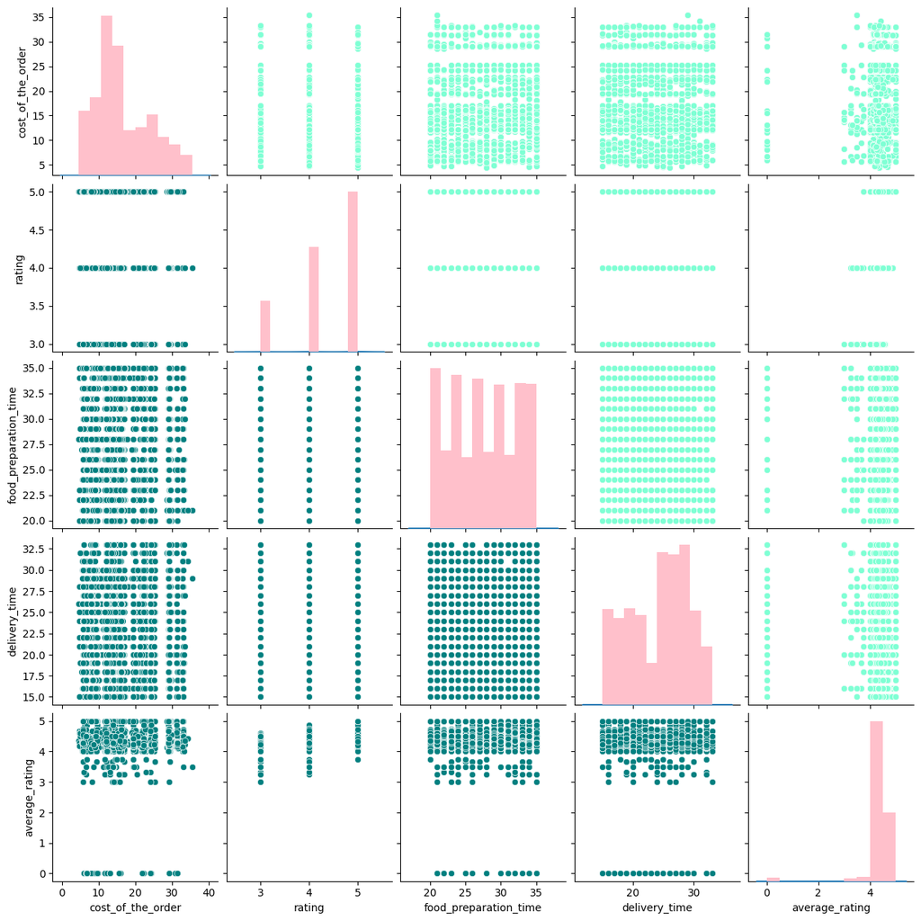

```python
g=sns.pairplot(data=df, diag_kind="kde")
g.map_upper(sns.scatterplot, color='aquamarine')
g.map_lower(sns.scatterplot, color='teal')
g.map_diag(plt.hist,color='pink')
plt.show();
```

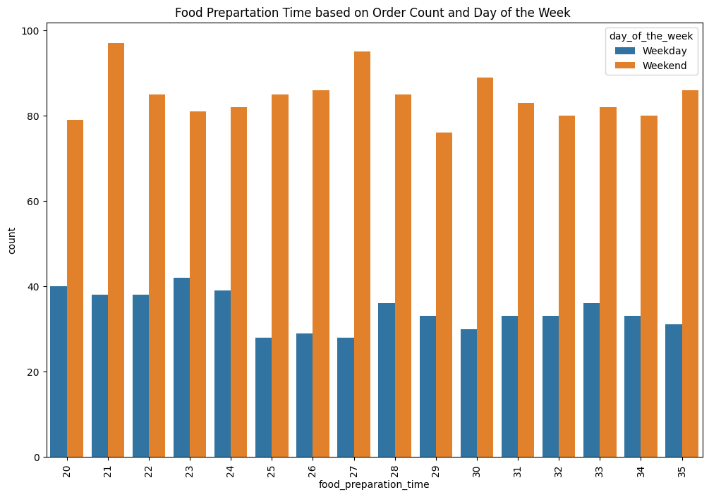

```python
plt.figure(figsize=(12,8))
sns.countplot(data= df, x='food_preparation_time', hue='day_of_the_week')
plt.title('Food Prepartation Time based on Order Count and Day of the Week ')
plt.xticks(rotation=90);
```

[output not shown]

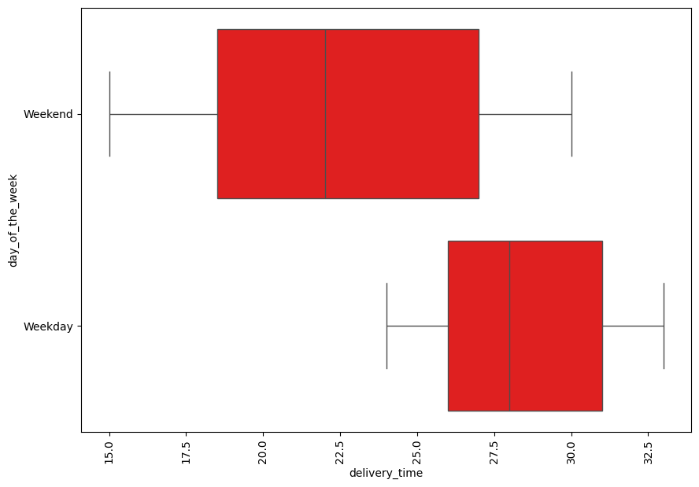

```python
# Boxplot showing delivery time based on ay of the week
plt.figure(figsize = (10,7))
sns.boxplot (data =df, y ='day_of_the_week', x = 'delivery_time', color = 'Red')
plt.xticks(rotation = 90)
plt.show()
```

**Observation**

There is no big correlation betweeen the numerical variables.

One thing I noticed was on Weekends based on order count the most often food preparation times were 21 minutes and 27 minutes, whereas on the weekdays the most often food preparation times were 20 and 23.

Delivery time on the Weekdays take longer than Delivery time on the weekends, this could be the result of traffic or could be a result of more orders being able to be delivered on the same run. For example, if there are multiple orders at the same restaurant that are ready about the same time, the delivery driver could take them all at the same time and deliver them to the customers if the customers are close together in distance. This is less likely to happen on a Weekday as there are a lot fewer orders.

### **Question 13:** The company wants to provide a promotional offer in the advertisement of the restaurants. The condition to get the offer is that the restaurants must have a rating count of more than 50 and the average rating should be greater than 4. Find the restaurants fulfilling the criteria to get the promotional offer. [3 marks]

```python
# Filter out any ratings equal to Nan
filtered_df = df[df['rating'].notnull()]
filtered_df
print()

# Filter on Ratings higher than 4
new_rating_higer_than_4 = filtered_df[filtered_df['average_rating']>4]
new_rating_higer_than_4.groupby('restaurant_name')['average_rating'].mean().sort_values(ascending=False).reset_index(name = 'average_rating')
print()

# Count the ratings per restaurant.head(10)
rating_counts_df = filtered_df.groupby(['restaurant_name','average_rating'])['rating'].count().sort_values(ascending=False).reset_index(name = 'rated_orders_per_restaurant')

# Rating counts >50
popular_restaurants = rating_counts_df[rating_counts_df['rated_orders_per_restaurant']>50]
popular_restaurants
```

|  | order_id | customer_id | restaurant_name | cuisine_type | cost_of_the_order | day_of_the_week | rating | food_preparation_time | delivery_time | average_rating |
| --- | --- | --- | --- | --- | --- | --- | --- | --- | --- | --- |
| 2 | 1477070 | 66393 | Cafe Habana | Mexican | 12.23 | Weekday | 5.00 | 23 | 28 | 4.27 |
| 3 | 1477334 | 106968 | Blue Ribbon Fried Chicken | American | 29.20 | Weekend | 3.00 | 25 | 15 | 4.33 |
| 4 | 1478249 | 76942 | Dirty Bird to Go | American | 11.59 | Weekday | 4.00 | 25 | 24 | 4.00 |
| 5 | 1477224 | 147468 | Tamarind TriBeCa | Indian | 25.22 | Weekday | 3.00 | 20 | 24 | 4.40 |
| 7 | 1477859 | 89574 | Barbounia | Mediterranean | 5.97 | Weekday | 3.00 | 33 | 30 | 4.50 |
| ... | ... | ... | ... | ... | ... | ... | ... | ... | ... | ... |
| 1889 | 1478190 | 94152 | RedFarm Broadway | Chinese | 8.68 | Weekday | 3.00 | 33 | 30 | 4.24 |
| 1890 | 1477316 | 164776 | TAO | Japanese | 15.67 | Weekend | 5.00 | 20 | 22 | 4.36 |
| 1893 | 1476701 | 292602 | Chipotle Mexican Grill $1.99 Delivery | Mexican | 22.31 | Weekend | 5.00 | 31 | 17 | 4.20 |
| 1894 | 1477421 | 397537 | The Smile | American | 12.18 | Weekend | 5.00 | 31 | 19 | 4.42 |
| 1896 | 1477513 | 64151 | Jack's Wife Freda | Mediterranean | 12.18 | Weekday | 5.00 | 23 | 31 | 4.32 |

1162 rows × 10 columns

|  | restaurant_name | average_rating |
| --- | --- | --- |
| 0 | 'wichcraft | 5.00 |
| 1 | Cipriani Le Specialita | 5.00 |
| 2 | Dig Inn Seasonal Market | 5.00 |
| 3 | Philippe Chow | 5.00 |
| 4 | Dos Caminos | 5.00 |
| ... | ... | ... |
| 105 | Cafe Mogador | 4.15 |
| 106 | ilili Restaurant | 4.15 |
| 107 | Parm | 4.13 |
| 108 | Rubirosa | 4.12 |
| 109 | Bareburger | 4.06 |

110 rows × 2 columns

|  | restaurant_name | average_rating | rated_orders_per_restaurant |
| --- | --- | --- | --- |
| 0 | Shake Shack | 4.28 | 133 |
| 1 | The Meatball Shop | 4.51 | 84 |
| 2 | Blue Ribbon Sushi | 4.22 | 73 |
| 3 | Blue Ribbon Fried Chicken | 4.33 | 64 |

**Observations**

110 Restaurants have a mean score higher than 4.

4 Restaurants have over 50 ratings.

As a result, I have determined 4 companies would qualify for the discount based on an average rate higher than 4 and a ratings count higher than 50. Those companies are Shake Shack, The Meatball Shop, Blue Ribbon Sushi, Blue Ribbon Fried Chicken.

### **Question 14:** The company charges the restaurant 25% on the orders having cost greater than 20 dollars and 15% on the orders having cost greater than 5 dollars. Find the net revenue generated by the company across all orders. [3 marks]

```python
# Calculate the fee. The fee is the revenue.
# Assumption is there is no fee on cost less than $5

def fee_received(cost_of_the_order):
  if (cost_of_the_order>20):
    return cost_of_the_order*.25
  elif (cost_of_the_order<20) & (cost_of_the_order>5):
    return cost_of_the_order*.15
  else:
   return 0

df['revenue']=df['cost_of_the_order'].apply(fee_received)

df.info()
print()

df.head()
```

```
<class 'pandas.core.frame.DataFrame'>
Int64Index: 1898 entries, 0 to 1897
Data columns (total 11 columns):
 #   Column                 Non-Null Count  Dtype
---  ------                 --------------  -----
 0   order_id               1898 non-null   object
 1   customer_id            1898 non-null   object
 2   restaurant_name        1898 non-null   object
 3   cuisine_type           1898 non-null   object
 4   cost_of_the_order      1898 non-null   float64
 5   day_of_the_week        1898 non-null   object
 6   rating                 1162 non-null   float64
 7   food_preparation_time  1898 non-null   int64
 8   delivery_time          1898 non-null   int64
 9   average_rating         1898 non-null   float64
 10  revenue                1898 non-null   float64
dtypes: float64(4), int64(2), object(5)
memory usage: 177.9+ KB
```

|  | order_id | customer_id | restaurant_name | cuisine_type | cost_of_the_order | day_of_the_week | rating | food_preparation_time | delivery_time | average_rating | revenue |
| --- | --- | --- | --- | --- | --- | --- | --- | --- | --- | --- | --- |
| 0 | 1477147 | 337525 | Hangawi | Korean | 30.75 | Weekend | NaN | 25 | 20 | 0.00 | 7.69 |
| 1 | 1477685 | 358141 | Blue Ribbon Sushi Izakaya | Japanese | 12.08 | Weekend | NaN | 25 | 23 | 4.33 | 1.81 |
| 2 | 1477070 | 66393 | Cafe Habana | Mexican | 12.23 | Weekday | 5.00 | 23 | 28 | 4.27 | 1.83 |
| 3 | 1477334 | 106968 | Blue Ribbon Fried Chicken | American | 29.20 | Weekend | 3.00 | 25 | 15 | 4.33 | 7.30 |
| 4 | 1478249 | 76942 | Dirty Bird to Go | American | 11.59 | Weekday | 4.00 | 25 | 24 | 4.00 | 1.74 |

```python
revenue_per_restaurant = df[['restaurant_name','revenue']].groupby('restaurant_name').sum().sort_values(by ='revenue', ascending = False).head(5)
revenue_per_restaurant
```

| restaurant_name | revenue |
| --- | --- |
| Shake Shack | 703.61 |
| The Meatball Shop | 419.83 |
| Blue Ribbon Sushi | 360.46 |
| Blue Ribbon Fried Chicken | 340.20 |
| Parm | 218.56 |

```python
# Total revenue rounded to 2 decimal points
revenue = round(df['revenue'].sum(),2)
revenue

# Create a count for orders that cost less than $5
cost_less_than_five = df[df['cost_of_the_order']<5].shape[0]
cost_less_than_five

# Total number of all orders
total_orders = df['order_id'].count()
total_orders

# Calculate a percentage of orders over $20
cost_percentage_below5 =  round((cost_less_than_five/total_orders)*100,2)
cost_percentage_below5
```

```
6166.3
```

```
9
```

```
1898
```

```
0.47
```

**Observations**

```python
print('Total revenue generated by the fees is ${}'.format(revenue),end='0. I am assumming there is no charge if the order cost less than $5.')
print()
print("There are", cost_less_than_five, "orders that have a cost less than $5.")
print('The total amount of orders is ${}'.format(total_orders),end='.')
print()
print(cost_percentage_below5,end = "% of orders cost less than $5.")
print('Based on the % less than $5, it should be decided if the company should implement a minium cost at a restaurant to allow delivery.')
print('Top 5 restaurants where revenue is generated is Shake Shack, The Meatball Shop, Blue Ribbon Sushi, Blue Ribbon Fried Chicken, and Parm.')
```

```
Total revenue generated by the fees is $6166.30. I am assumming there is no charge if the order cost less than $5.
There are 9 orders that have a cost less than $5.
The total amount of orders is $1898.
0.47% of orders cost less than $5.Based on the % less than $5, it should be decided if the company should implement a minium cost at a restaurant to allow delivery.
Top 5 restaurants where revenue is generated is Shake Shack, The Meatball Shop, Blue Ribbon Sushi, Blue Ribbon Fried Chicken, and Parm.
```

### **Question 15:** The company wants to analyze the total time required to deliver the food. What percentage of orders take more than 60 minutes to get delivered from the time the order is placed? (The food has to be prepared and then delivered.) [2 marks]

```python
df['time'] = (df['delivery_time']+df['food_preparation_time'])
df.info()
df.head()
```

```
<class 'pandas.core.frame.DataFrame'>
Int64Index: 1898 entries, 0 to 1897
Data columns (total 12 columns):
 #   Column                 Non-Null Count  Dtype
---  ------                 --------------  -----
 0   order_id               1898 non-null   object
 1   customer_id            1898 non-null   object
 2   restaurant_name        1898 non-null   object
 3   cuisine_type           1898 non-null   object
 4   cost_of_the_order      1898 non-null   float64
 5   day_of_the_week        1898 non-null   object
 6   rating                 1162 non-null   float64
 7   food_preparation_time  1898 non-null   int64
 8   delivery_time          1898 non-null   int64
 9   average_rating         1898 non-null   float64
 10  revenue                1898 non-null   float64
 11  time                   1898 non-null   int64
dtypes: float64(4), int64(3), object(5)
memory usage: 192.8+ KB
```

|  | order_id | customer_id | restaurant_name | cuisine_type | cost_of_the_order | day_of_the_week | rating | food_preparation_time | delivery_time | average_rating | revenue | time |
| --- | --- | --- | --- | --- | --- | --- | --- | --- | --- | --- | --- | --- |
| 0 | 1477147 | 337525 | Hangawi | Korean | 30.75 | Weekend | NaN | 25 | 20 | 0.00 | 7.69 | 45 |
| 1 | 1477685 | 358141 | Blue Ribbon Sushi Izakaya | Japanese | 12.08 | Weekend | NaN | 25 | 23 | 4.33 | 1.81 | 48 |
| 2 | 1477070 | 66393 | Cafe Habana | Mexican | 12.23 | Weekday | 5.00 | 23 | 28 | 4.27 | 1.83 | 51 |
| 3 | 1477334 | 106968 | Blue Ribbon Fried Chicken | American | 29.20 | Weekend | 3.00 | 25 | 15 | 4.33 | 7.30 | 40 |
| 4 | 1478249 | 76942 | Dirty Bird to Go | American | 11.59 | Weekday | 4.00 | 25 | 24 | 4.00 | 1.74 | 49 |

```python
# Create a count for orders that took longer than 60 minutes to be received by customers
greater_than_hour = df['time'][df['time']>60].count()
greater_than_hour

# Total time needed to delivery all orders
total_orders_time = df['time'].sum()
total_orders_time

# % of all order than take longer than an hour from order to delivery
greater_than_hour_percentage =  round((greater_than_hour/order_count.sum())*100,2)
greater_than_hour_percentage
```

```
200
```

```
97811
```

```
10.54
```

**Observations**

```python
print("The count of orders than took greater than an hour from order to delivery is", greater_than_hour,'out of',order_count.sum(),end='.')
print()
print("The total time of all orders is",total_orders_time,end='.')
print()
print(greater_than_hour_percentage,end = "% of all orders took over an hour to be delivered after they were ordered.")
```

```
The count of orders than took greater than an hour from order to delivery is 200 out of 1898.
The total time of all orders is 97811.
10.54% of all orders took over an hour to be delivered after they were ordered.
```

### **Question 16:** The company wants to analyze the delivery time of the orders on weekdays and weekends. How does the mean delivery time vary during weekdays and weekends? [2 marks]

```python
#Calculate the average per day (Weekend vs Weekday)
delivery_time_by_day = df.groupby('day_of_the_week')['delivery_time'].mean()
print(delivery_time_by_day)
print()

#Create a count per day (Weekend vs Weekday)
orders_by_day = df.groupby('day_of_the_week')['order_id'].count()
print(orders_by_day)
print()

delivery_time_difference = round(weekday.delivery_time.mean()-weekend.delivery_time.mean(),2)
delivery_time_difference
```

```
day_of_the_week
Weekday   28.34
Weekend   22.47
Name: delivery_time, dtype: float64

day_of_the_week
Weekday     547
Weekend    1351
Name: order_id, dtype: int64
```

```
5.87
```

**Observations**

The average delivery time took longer when there were less orders.

The average delivery time on a Weekday was 28.34 minutes to deliver 547 orders whereas it was 22.47 minutes to deliver 1351 orders on a Weekend.

To understand these differences would need to get information about distances from the restaurant and other order's addresses to see if the distance can explain the variances in time differences.

### Conclusion and Recommendations

### **Question 17:** What are your conclusions from the analysis? What recommendations would you like to share to help improve the business? (You can use cuisine type and feedback ratings to drive your business recommendations.) [6 marks]

### Conclusions

**Recommendations**

Would recommend offering an incentive for rating the service. 736 ratings out of 1898 orders were not rated. That is 38.78% of all the orders. These ratings are very important in knowing how well the company is doing. These ratings should be broken into categories: food, delivery. Breaking it out will help you know whether it is the service or the food they did not like. Once ratings are broken in to food versus delivery you will be able to see which drivers are getting the lowest ratings. This will help you determine if there is an issue with one of your drivers causing the customers to give a lower rating and potentially not use the service again.

Revenue earned per restaurant should be looked at closely. The restaurants where the least revenue is being made, a decision should be made whether to keep delivering for them. The bottom 10 restaurants based on order cost make up only 0.23% of all order cost. Since revenue is based on order cost this would be something that I would recommend having a deeper analysis on.

87.58% of customers ordered 2 or less times. This is something that should be explored more to determine why. This goes back to the ratings. Were the customers dissatisfied with the food, dissatisfied with the service, or is there some other reason they order such few times?

It would be beneficial to get distance information. You would be able to do a more in-depth analysis of delivery time if you had information about the distance between the restaurant and the customer the food is being delivered to. This will also help you optimize your delivery time. You can assign multiple orders to the same driver if the restaurants and customers are within a certain distance from each other. This could be used when one restaurant has a few customers who have ordered that are close to each other and their food will be available for pickup at around the same time.

Only 28.8% of all orders took place on a weekday. There are discount/incentive opportunities that could be looked at to increase the weekday number of orders.

```python
%%shell
jupyter nbconvert --to html //'/content/drive/MyDrive/Python Course/Project 1/PYF_Project_LearnerNotebook_FullCode.ipynb'
```

```
[NbConvertApp] Converting notebook ///content/drive/MyDrive/Python Course/Project 1/PYF_Project_LearnerNotebook_FullCode.ipynb to html
[NbConvertApp] Writing 804943 bytes to /content/drive/MyDrive/Python Course/Project 1/PYF_Project_LearnerNotebook_FullCode.html
```